# Assignment 12: Predictive Modeling - Part 3

*How to do it?*:

- Open the Rmarkdown file of this assignment (link) in Rstudio.
- Right under each **question**, insert a code chunk (you can use the hotkey `Ctrl + Alt + I` to add a code chunk) and code the solution for the question.
- `Knit` the rmarkdown file (hotkey: `Ctrl + Alt + K`) to export an html.
- Publish the html file to your Githiub Page.

*Submission*: Submit the link on Github of the assignment to Blackboard.

1. Install the package `mlbench` and use the follows to import the data

```r
library(mlbench)
data(PimaIndiansDiabetes)
df <- PimaIndiansDiabetes
```

- Set seed to be 2020.
- The target variable is `diabetes`
- Partition the data into 80% training and 20% testing.

```r
# The target variable is the variable at column 9.
# Same as previous two assignments
names(df)[9] <- 'target'
library(caret)
set.seed(2020)
splitIndex <- createDataPartition(df$target, p = .80,
                                  list = FALSE)
df_train <- df[ splitIndex,]
df_test <- df[-splitIndex,]
```

2. Use cross-validation of 30 folds to tune random forest (method=‘rf’). What is the `mtry` value that produces the greatest accuracy?

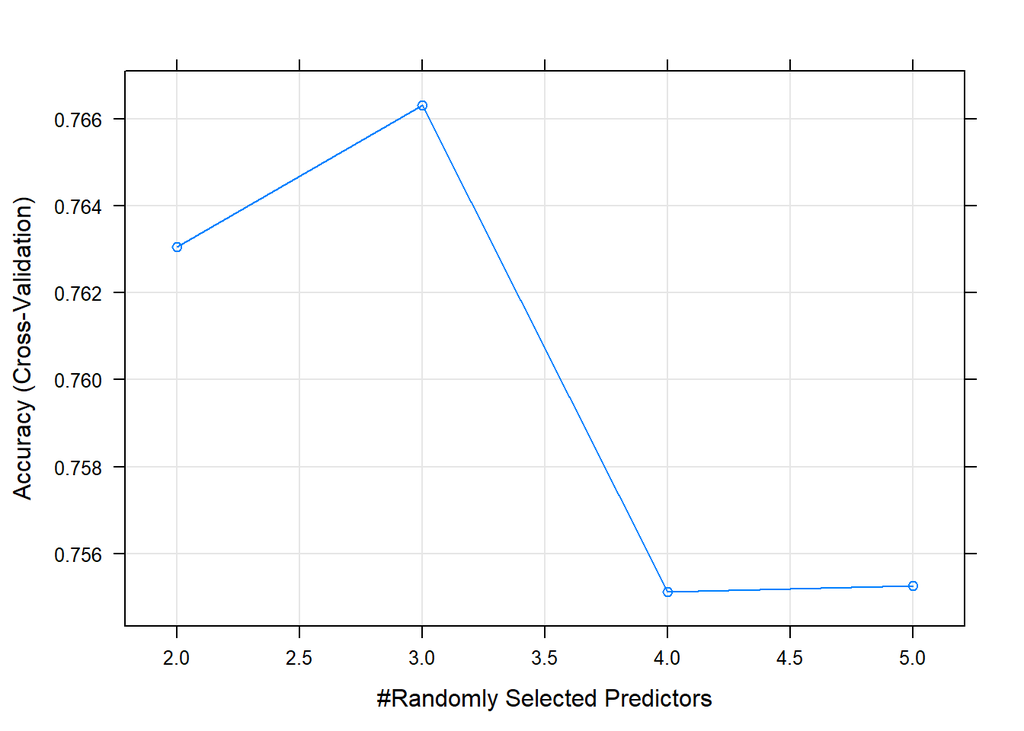

```r
# Decide the range of the maxdepth to search for the best
#9 variables in dataset and 1 is target, so only try up to 8 (using 5 to run it faster)
tuneGrid = expand.grid(mtry = 2:5)
# Tell caret to do 30 folds cross-Validation
trControl = trainControl(method = "cv",
                         number = 30)
# train a forest using above setup
set.seed(2020)
forest_rf <- train(target~., data=df_train,
                                method = "rf",
                                trControl = trControl,
                                tuneGrid = tuneGrid)

plot(forest_rf)
```

```r
#mtry of 3 produces the best accuracy

pred <- predict(forest_rf, df_test)
cm <- confusionMatrix(data = pred, reference = df_test$target, positive = "pos")
cm$overall[1]
```

```
##  Accuracy
## 0.7777778
```

3. Use cross-validation with 30 folds to tune random forest (method=‘ranger’). What are the parameters that produce the greatest accuracy?

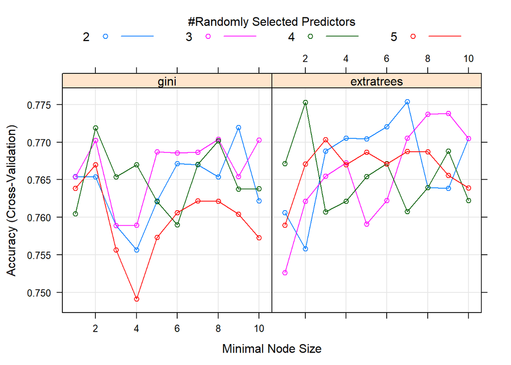

```r
#set 30 folds for cv - actually went with 20 becuase 30 was too many errors
trControl = trainControl(method = "cv",
                         number = 20)
#mtry can go 2:8 (2:5 to run it faster), test gini or extratrees, try many min node size (could do more, just long time to run)
tuneGrid = expand.grid(mtry = 2:5,
                       splitrule = c('gini', 'extratrees'),
                       min.node.size = c(1:10))
set.seed(2020)
forest_ranger <- train(target~., data=df_train,
                    method = "ranger",
                    trControl = trControl,
                    tuneGrid = tuneGrid)
plot(forest_ranger)
```

```r
#Greatest accuracy at extratrees, 2 predictors, 7 minimum node size

pred <- predict(forest_ranger, df_test)
cm <- confusionMatrix(data = pred, reference = df_test$target, positive = "pos")
cm$overall[1]
```

```
##  Accuracy
## 0.7712418
```

4. Go to https://topepo.github.io/caret/available-models.html and pick a classification model. Tune the classification model using cross-validation of 30 folds.

```r
trControl = trainControl(method = "cv",
                         number = 30)

ownn <- train(target~., data=df_train,
                                method = "ownn",
                                trControl = trControl)

pred <- predict(ownn, df_test)
cm <- confusionMatrix(data = pred, reference = df_test$target, positive = "pos")
cm$overall[1]
```

```
##  Accuracy
## 0.7581699
```

5. Pick three models at [this link](https://topepo.github.io/caret/available-models.html) to compare using 15-fold cross validation method. Evaluate the accuracy of the final model on the test data. What is the best model?

```r
trControl = trainControl(method = "cv",
                         number = 15)
model1 <- train(target~., data=df_train,
                                method = "rocc",
                                trControl = trControl)
model2 <- train(target~., data=df_train,
                    method = "ownn",
                                trControl = trControl)
model3 <- train(target~., data=df_train,
                                method = "pam",
                                trControl = trControl)
```

```
## 1234567891011121314151617181920212223242526272829301111111111111111
```

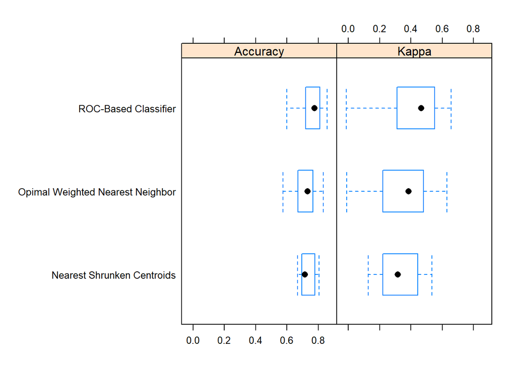

```r
results <- resamples(list('ROC-Based Classifier' = model1,
                          'Opimal Weighted Nearest Neighbor' = model2,
                          'Nearest Shrunken Centroids'= model3))
bwplot(results)
```

```r
#All models fairly similar accuracy, ROC-based is slightly better
```

6. Redo Question 5 on this following dataset.
- `Adult Census Income` dataset ([Link](https://www.kaggle.com/uciml/adult-census-income)) where the target variable is `income`

```r
library(tidyverse)
df3 <-read_csv("C:\\Users\\student\\Desktop\\R 421\\adult.csv")
df3 <- drop_na(df3)
df3$target <- case_when(
  df3$income =="<=50K" ~ 0,
  df3$income ==">50K" ~ 1,
  TRUE ~ 0)
df3 <- select(df3,-income)

df3$target <- factor(df3$target)
#next line makes data set smaller to run quicker
df3 <- sample_n(df3,2000)
library(caret)
set.seed(2020)
splitIndex <- createDataPartition(df3$target, p = .80,
                                  list = FALSE)
df3_train <- df3[ splitIndex,]
df3_test <- df3[-splitIndex,]

#using less folds to make models run quicker
trControl = trainControl(method = "cv",
                         number = 5)
model1 <- train(target~., data=df3_train,
                                method = "rocc",
                                trControl = trControl)
model2 <- train(target~., data=df3_train,
                    method = "ownn",
                                trControl = trControl)
model3 <- train(target~., data=df3_train,
                                method = "pam",
                                trControl = trControl)
```

```
## 123456789101112131415161718192021222324252627282930111111
```

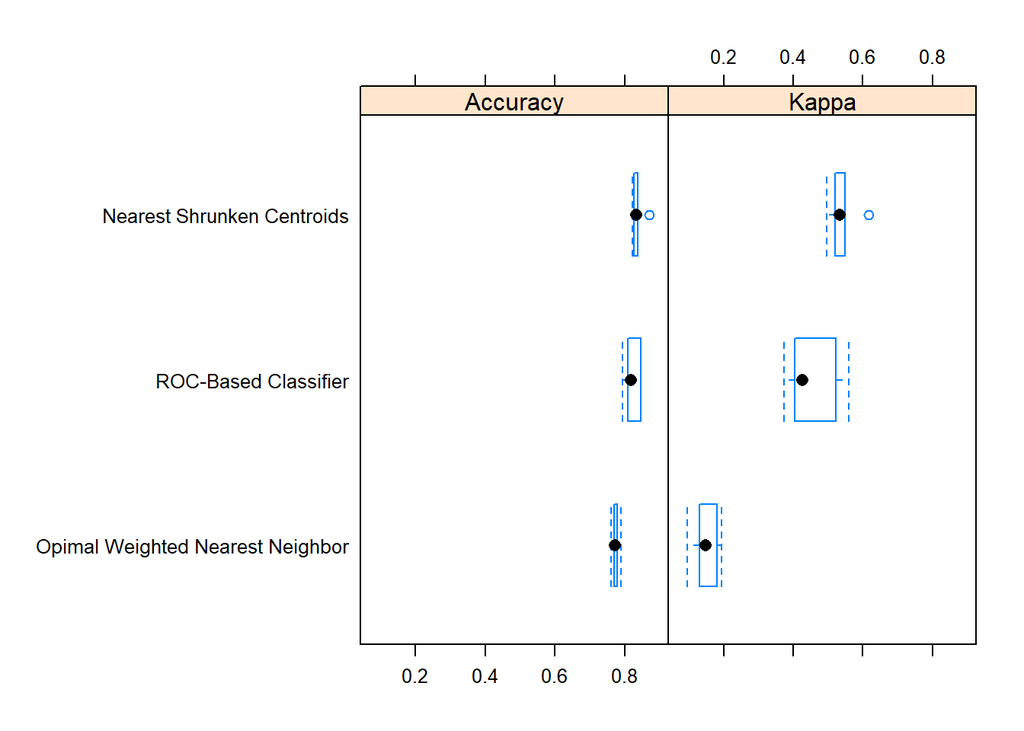

```r
results <- resamples(list('ROC-Based Classifier' = model1,
                          'Opimal Weighted Nearest Neighbor' = model2,
                          'Nearest Shrunken Centroids'= model3))
bwplot(results)
```

```r
#All models fairly similar accuracy again, nearest shrunked centroids is slightly better
```

- `Credit card default` dataset ([link](https://www.kaggle.com/uciml/default-of-credit-card-clients-dataset)) where the target variable is `default.payment.next.month`

```r
library(tidyverse)
df2 <-read_csv("C:\\Users\\student\\Desktop\\R 421\\UCI_Credit_Card.csv")

names(df2)[25] <- 'target'
#Naming target variable
df2$target <- factor(df2$target)
#making a smaller sample to help code run quicker
df2 <- sample_n(df2,2000)
library(caret)
set.seed(2020)
splitIndex <- createDataPartition(df2$target, p = .80,
                                  list = FALSE)
df2_train <- df2[ splitIndex,]
df2_test <- df2[-splitIndex,]

#only five folds to help code speed
trControl = trainControl(method = "cv",
                         number = 5)
model1 <- train(target~., data=df2_train,
                                method = "rocc",
                                trControl = trControl)
model2 <- train(target~., data=df2_train,
                    method = "ownn",
                                trControl = trControl)
model3 <- train(target~., data=df2_train,
                                method = "pam",
                                trControl = trControl)
```

```
## 123456789101112131415161718192021222324252627282930111111
```

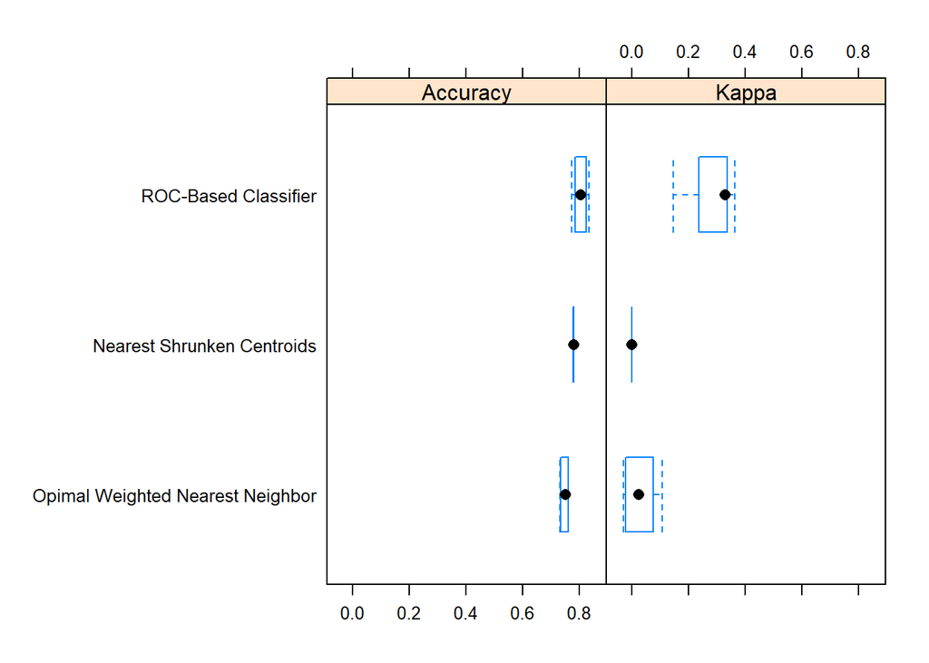

```r
results <- resamples(list('ROC-Based Classifier' = model1,
                          'Opimal Weighted Nearest Neighbor' = model2,
                          'Nearest Shrunken Centroids'= model3))
bwplot(results)
```

```r
#Again, all models have similar results, ROC back to being the best model.
```